# Stockdale Exploratory Analysis with 298 Markers

### Plot by lineage

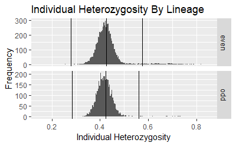

How many fish would we lose if we went with these cutoffs?

```r
# Upper cutoff only, lower doesn't apply
het_tibble %>%
  dplyr::group_by(lineage) %>%
  dplyr::summarise(upper = mean(het) + 3* sd(het)) %>%
  dplyr::right_join(het_tibble) %>%
  dplyr::filter(het >= upper) %>%
  dplyr::count(lineage)
```

| lineage | n |
| --- | --- |
| even | 158 |
| odd | 78 |

### Cutoffs to remove outliers

If we went with the 3SD cutoff, we would lose 78 samples from the odd lineage and 158 from the even. Still, this +-3SD by lineage approach does not seem ideal given the large number of outliers that **pull** the SD. We can see this long right tail with a qqplot.

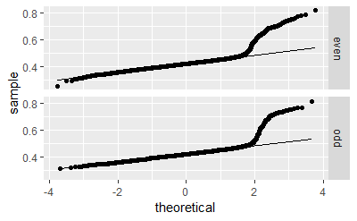

Same idea, but with a boxplot. **Note** all points are 1.5 IQR +- upper/lower boxplot. Perhaps we could use this 1.5 IQR approach for removing outliers?

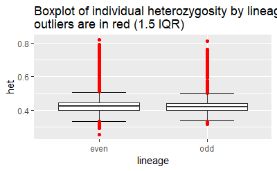

Chris suggested that we stick with the +-3SD approach, however, before calculating the SD, we mirror the left hand side of the distribution to the right (assuming the **mode** should be the **mean**).

| lineage | het_mean | het_lower_3sd | het_upper_3sd |
| --- | --- | --- | --- |
| even | 0.4177631 | 0.3268485 | 0.5086777 |

Now lets look at all three of these approaches on the original histograms.

1. +-3SD by lineage
2. 1.5 IQR +- 75% and 25% quartiles
3. Chris’ +-3SD by lineage only using the left hand side of the distribution.

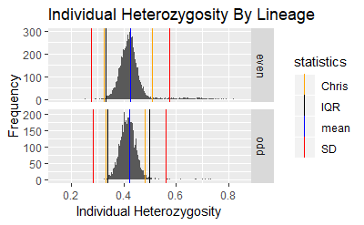

We can see that the upper bound is virtually identical for both Chris’ method and IQR. We proposed that we go with the 1.5 IQR method given that it is well known and well documented. All agreed.

### Remove fish with IQR cutoff

Now that we’ve decided to use the 1.5IQR, how many fish are we going to remove from each silly?

| silly | n |
| --- | --- |
| PSTOCK13 | 6 |
| PSTOCK14 | 19 |
| PSTOCK15 | 117 |
| PSTOCK16 | 233 |

Now remove those fish. Figure out which ones they are, convert *SillySource* to *FK_FISH_ID* (**note**: the values for *FK_FISH_ID* got reassigned after pooling), remove them.

```r
RemoveIDs.GCL(silly = "PSTOCK16", IDs = PSTOCK16_hets_remove)
```

## Final

How many fish did we end up with?

```r
ProjectSillys_Origin_SampleSizes
```

```
          Genotyped Missing Duplicate Heterozygosity Final
PSTOCK13n       871      54         0              6   811
PSTOCK13h       182      19         0              0   163
PSTOCK14n       436      65         4              9   358
PSTOCK14h       512      66         0             10   436
PSTOCK15       3347     125        12            117  3093
PSTOCK16       7038    1560        46            233  5199
```

Save post-QA genotypes.

# Export genepop file

Now that we have final, post QA/QC genotypes, we want to save our work by exporting the genotypes as a **Genepeop** file. That **Genepop** file will then feed in to Chase’s *genepop2franz.GCL.r* script to create a **FRANz** input file for parentage analysis!

Create a *genepop* using `gcl2Genepop.GCL`, individuals are named by *SillySource*.

```r
gcl2Genepop.GCL(sillyvec = c("PSTOCK14n", "PSTOCK14h", "PSTOCK16"),
                loci = loci,
                path = "V:/Analysis/5_Coastwide/Multispecies/Alaska Hatchery Research Program/PWS Pink/Genepop/stockdale/stockdale_even_postQA.gen",
                VialNums = TRUE,
                usat = FALSE)
```

# Convert genepop to Franz

```r
genepop2franz.GCL("V:/Analysis/5_Coastwide/Multispecies/Alaska Hatchery Research Program/PWS Pink/Genepop/Stockdale/stockdale_postQA.gen", "V:/Analysis/5_Coastwide/Multispecies/Alaska Hatchery Research Program/PWS Pink/OceanAK/PedigreeData_AHRP - Salmon Biological Data 2_PWS_2013-2018_no_otoliths.csv", c(2014, 2016), "STOCK", "../")
```

```
 Converting data from a Genepop .gen file to a genind object...


File description:  GENEPOP input format

...done.
```